# Planning optimal fire mosaics- initial findings

Chris Adlam

10/2018

# Overview

**Project aims:**

- Evaluate the effect of fire severity and time (and, conversely, lack of fire) on native plant, bird, lichen and insect communities in the WKRP area;
- Suggest proportions of each habitat on the landscape that would maximize species diversity;
- Make management recommendations for forest restoration treatments that will be most likely to maximize biodiversity.

**Methods:**  
Surveys were conducted at 48 sites divided into long-unburnt (hereafter UN), low severity (hereafter LS) and high severity (hereafter HS) fire, ranging from 4 to 31 years since last fire. No repeat burns were studied.

Sampling methods involved: surveys of all native plants and lichens (growing on trees) within an 11.3m radius circle; two 10-minute bird point counts; one flight-intercept trap left for 2 days to passively collect flying insects. Preliminary data for plants and birds are presented here. Lichen and insect specimens are still being identified (completion expected by December 2018).

# Results

### NMDS

#### plants

Non-metric multidimensional scaling (NMDS) is a way to graphically represent the difference between sampling sites. In the following graph, each point represents a site, and the distance between two points is proportional to the difference in the species composition at each site. The axes don’t necessarily reflect ecologically meaningful factors.

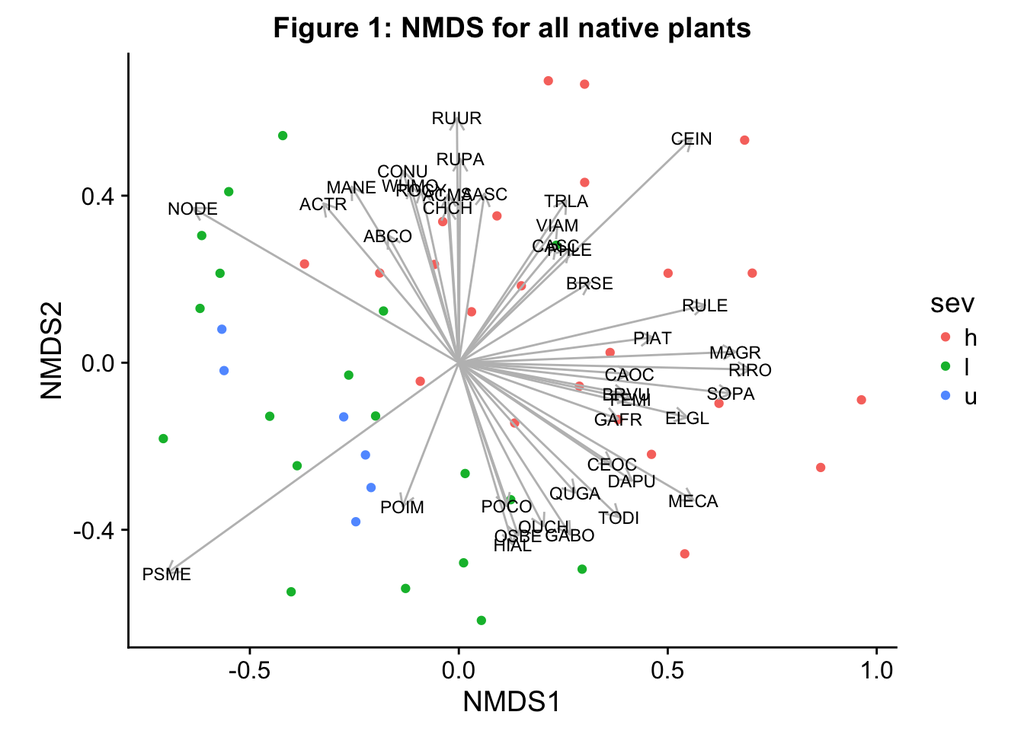

The NMDS using all native plants suggests no difference between unburnt and LS, but HS is very different (figure 1). Douglas-fir (PSME) cover is much higher in LS/UN, whereas deerbrush (CEIN) cover is highest in the HS. Other species that are strongly associated with one habitat are investigated below (see indicator species analysis). Time-since-fire was not included in this analysis.

Interestingly, the number of species in high severity and low severity is not statistically different on a plot-by-plot basis (see Fig. 2). However there are two important contrasts between HS and LS:

- the NMDS shows that the species composition is different even if species richness isn’t (figure 1), and
- there are more species restricted to HS areas that species restricted to LS/UN areas (42 out of 139 species collected were only found in HS burns vs. only 16 species found in LS or UN areas but not in HS).

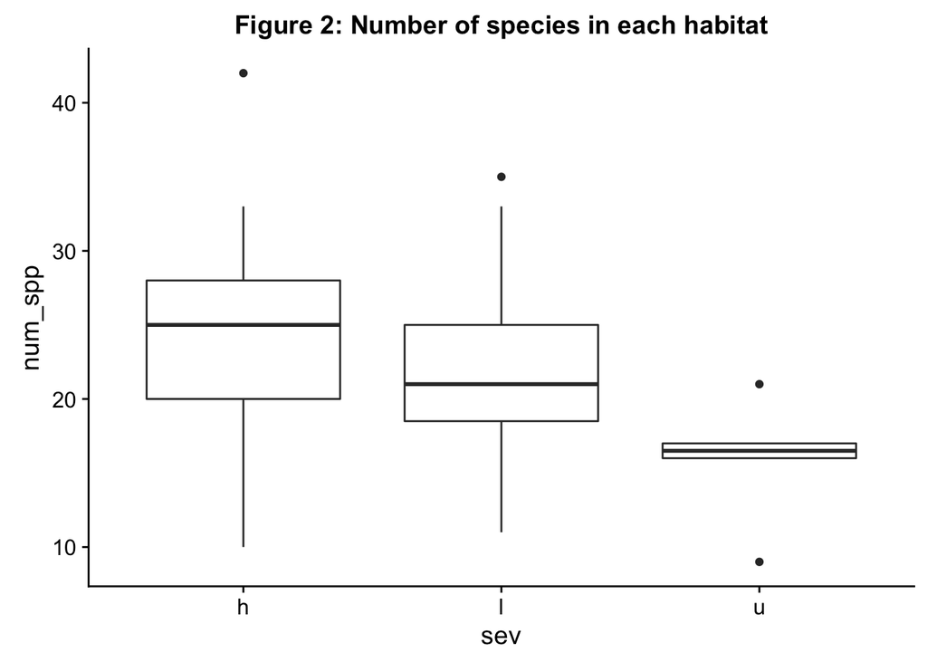

Table 1: species restricted to only HS or LS/UN

[output not shown]

| Species found only in LS/UN |
| --- |
| Adenocaulon bicolor |
| Aralia californica |
| Cardamine californica |
| Chimaphila umbellata |
| Corallorhiza striata |
| Dryopteris arguta |
| Goodyera oblongifolia |
| Linnaea borealis |
| Nemophila parviflora |
| Stachys mexicana |
| Umbellularia californica |
| Vitis californica |
| Viola lobata |
| Woodwardia fimbriata |
| Allium sp |
| Oemleria cerasiformis |

#### Birds

The NMDS for birds shows a very similar picture to the NMDS for plants (figure 2). The HS sites are clearly different from the LS and UN sites. There is a clear differentiation between species that favor one habitat or the other.

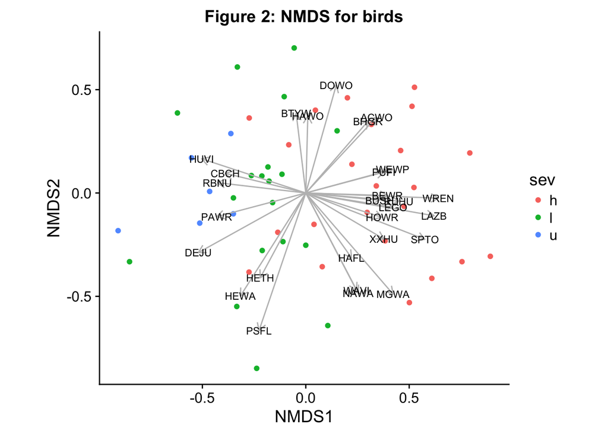

### PERMANOVA (plants)

A permanova analysis shows that there is a strong effect of severity on plants (only native species used in the analysis), and a weaker effect of TSF. A pairwise comparison indicates that there is no statistically significant difference between unburnt and LS sites, but that HS sites differ in species composition. Further analysis incorporating TSF is needed.

Table 2: PERMANOVA results

|  | Df | SumOfSqs | F | Pr(>F) |
| --- | --- | --- | --- | --- |
| sev | 2 | 3.14 | 8.29 | 0.00 |
| tsf_cat | 2 | 0.83 | 2.18 | 0.02 |
| sev:tsf_cat | 2 | 0.31 | 0.82 | 0.65 |
| Residual | 41 | 7.77 | NA | NA |

### Indicator species analysis

The indicator species analysis reveals which species are strongly tied to HS and LS/UN habitats (the latter are grouped since the PERMANOVA suggested they were not very different). Further exploration of species preferences using linear models is in progress.

In brief, species associated with high severity burns include native grasses, shrubs, and annuals, whereas species of closed-canopy stands include sword fern, vanilla leaf, and pathfinder. Unsurprisingly, high cover of Douglas-fir is indicative of low severity fire.

Table 3: Indicator species for different habitats

| Species | Indicator value |
| --- | --- |
| Ceanothus integerrimus | 87 |
| Toxicodendron diversilobum | 61 |
| Ribes roezlii | 53 |
| Melica californica | 50 |
| Madia gracilis | 50 |
| Rubus leucodermis | 44 |
| Elymus glaucus | 41 |
| Campanula scouleri | 35 |
| Solanum parishii | 31 |
| Festuca microstachys | 30 |
| Rubus ursinus | 25 |
| Bromus secalinus | 22 |
| Daucus pusillus | 22 |

| Species | Indicator value |
| --- | --- |
| Pseudotsuga menziesii | 91 |
| Anisocarpus madioides | 48 |
| Polystichum imbricans | 40 |
| Adenocaulon bicolor | 28 |
| Achlys triphylla | 24 |

### Growth-stage optimization

#### GSO: plants

In a nutshell, the growth-stage optimization method (GSO) uses an algorithm to produce optimal proportions of different habitats that would maximize the abundance of all species across a landscape. It has been used in Australia to produce actionable targets for fire managers to achieve the best results for biodiversity. In this case, I divided the landscape into high severity (HS), low severity (LS), and unburnt (UN), with two age categories for HS and LS: 4-12 years since fire (1), and 16-31 years since fire (2). The GSO for plants suggests that ~80% of the landscape should be burnt at high severity, with the rest divided into low severity and unburnt (Fig. 3), but see discussion for how to interpret this startling result.

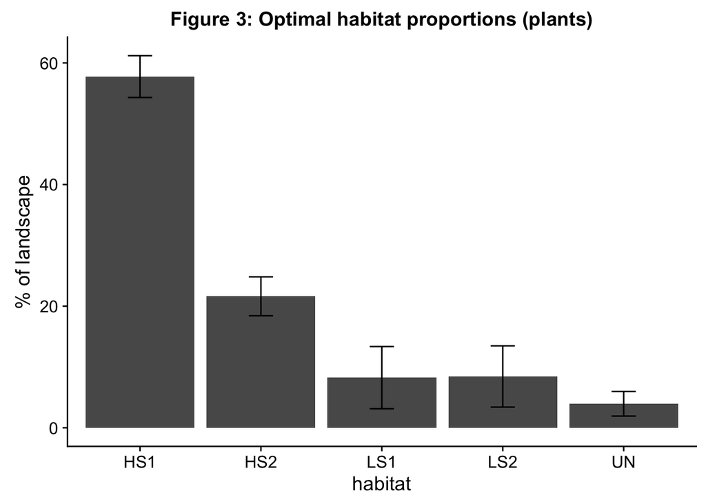

#### GSO: birds

The GSO for birds is similar to that for plants (Fig. 4). The optimal proportion of habitats to maximize biodiversity would include a large proportion of HS fire, and closed canopy (LS or UN) representing roughly a quarter of the landscape.

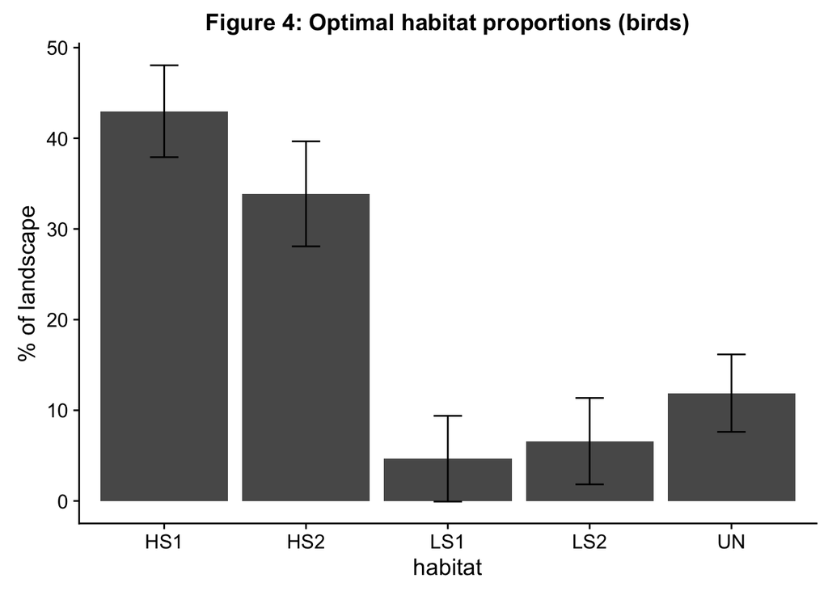

# Discussion and next steps

My data show that high severity areas are important for biodiversity compared to fire-suppressed stands, even those that have burnt once at low severity. HS burns provide habitat to numerous species not found in fire-suppressed stands, and the GSO reflects this by suggesting a vast proportion of the landscape should be burnt at high severity to achieve the highest biodiversity levels.

But although this result can be interpreted to mean that high severity fire is a normal and positive element in the fire regime of the Klamath Mountains and that a hands-off fire manegement approach is best, an alternative explanation is worth considering. Instead of highlighting the value of high severity burns, my data might be showing the **dramatic cost to biodiversity of fire suppression**. Historically, numerous species that occur today in high severity areas would likely have used open-canopied forests maintained by a more frequent fire regime. In such habitats, these species would have coexisted with those that require mature stands and partial canopy cover. Conversion to closed-canopy forests may have made vast areas unsuitable for open canopy species which now find themselves pushed into the only remain habitat they can use, high severity burns.

The resulting dichotomy between HS burns and closed-canopy stands may be a novel condition on the landscape. While calls for forest restoration are often concerned with reducing the risk of catastrophic fire, my data suggest that **the real catastrophe from a biodiversity perspective is the widespread canopy closure caused by fire suppression**. Therefore, rather than celebrating HS fire and vindicating advocates of hands-off approaches to fire management, my data might be pointing to the urgent need to restore closed canopy, fire-suppressed forests to their historical condition.

Needless to say, my sampling methods had their limitations as they only focussed on a subset of species. I did not survey many groups of organisms that might be tied to high canopy cover and mature stands, including bryophytes, molluscs, and amphibians. Additionally, a focus on species diversity in high severity burns ignores negative impacts of such fires, such as sedimentation, loss of legacy trees, and numerous cultural values. These matters would be discussed at greater length in the final product.

Additional research is needed to answer some questions that are prompted by these results:

- A single low severity fire seems to have little impact on biodiversity, but does frequent LS fire have a significant impact? Does frequent LS fire lead to lower canopy cover over time and does this enable species affiliated with HS burns to coexist within the same stand with species affiliated with closed-canopy stands?
- What was the historical understory like and how does it compare to what we see today in either high or low severity burns?

The first question can be answered by studying areas that have burnt multiple times, probably using prescribed fire. Though few such areas exist, using sites further afield (eg. the Rogue-Siskiyou National Forest) might be sufficient for such a study. Since my data suggest little benefit to biodiversity from a single burn, it would be interesting to see how management using multiple prescribed burns can achieve biodiversity enhancement goals.

The second question can be answered using phytolith analyses, which has not been done in the Klamath Mountains to my knowledge. However, I have no experience with this method, and it might be unwise to start down a new path (if I want to finish my degree in a timely manner), but the results might be worth the effort. I will investigate collaborating with experienced phytolith researchers at UC Berkeley.

back to top